# Recommendation Systems

There are some interesting recommendation libraries you can use in Python such as:

- Surprise
- Implicit

We are going to use the Job Recommendation Challenge from Kaggle, please be aware this is an eight years old challenge, however, we can show different methods that can be used. Plus, we are not taking into account the windows and the train and test information from source.

====================================================================================================================

We will not use utils.py file or something as support to be very transparent on what we are doing.

=====================================================================================================================

I have been working for the past 4 months in recommendations systems. This is not a guide to put into production a recommendation system, but to understand all the possibilities to enhace user experience through recommendations.

### What is a recommendation system

You have probaby use them when watching videos on Youtube or movies on Netflix or products in Amazon. But not only in those big organizations, but all websites that sell something might have some recommendations for users. For example a small brewing shop supply might have very naive recommendations, like brewing kits or very famous hops. This sytems are implemented to sell more through better user experience. They are part of information filtering systems.

### The beginning

Say you are a very small brewing shop and have no idea about recommendation systems but **need to put some products in your home page**, think about it, what would you do? I would say there are two easy solutions, top ordered items or random items; the latter is not a good idea actually, but the former is good. There is one problem, hopefully you will make users buy more of the top items and even less of the laggard items. But also, you will make niche users or experts way worse user experience. Just as a spoiler, experience shoppers might buy similar products.

### A little bit of theory

We will say a recommendation system is more of a **ranking** where you can have explicit or implicit ratings, for example, stars in Netflix recommender system, but also views in a particular movie. Now we can have **content-based** recommender systems or **knowledge-based** or **collaborative filtering**, from the latter you can have **user-based**, **item-based** (memory based) or **matrix-factorization** (recently adopted more exposure due to latent variable decomposition, dimensionality reduction).  
Now, for the small brewing shop content-based might be a very good approach, since we expect to have feasible business knowledge. For example we know people buying hops might also need yeast and grains, but not only that, we might even be able to recommend some chocolate grain if intersted in roasted and if interested in both even oat or wheat. So knowledge base systems are those were user have explicitly told you what he or she wants, for example I am a Stout/Porter brewer, I like those beers then it would be smart to recommend me that, also I do small batches from 5 to 20lts, then you can recommend me adequate materials.

### Scaling

Know imagine you have a huge brewing materials retail and you want to do content-based for brewing kits, you can do that through a **nearest-neighbor** or a **clustering** technique. Then recommend all items in that cluster or near that item. But to much of content-based, even though there were a ton more things to speak about, like grey and black ships (being in the border of clusters and very far from all clusters respectivally). Lets speak about **collaborative filtering, cold-start problem and explicit feedback**. From collaborative filtering, as explained above, we can have two approaches **memory-based** and **model-based**, the former finds similarity of users or items based on distance metric such as cosine or correlation (http://www.benfrederickson.com/distance-metrics/). The latter uses neural networks, PCA or matrix factorization.  
Specifically I will focus on matrix factorization, and I will jump abruptly to movie recommendations (since I like movies and small brewing shop makes no sense). Imagine you have rated items (stars, purchases, views, etc) by every user, first you will have a sparse matrix (since as a user you do not watch all movies) and probably you can get some cool information about each movie based on users preference; for example, Luis Serrano has a very nice point about the sinergy of users, say you average the users ratings of the **Twister movie** and **JAWS movie**, you might get **Sharknado movie**, of course this is an example, or similar movies getting same ratings like **Mall cop** and **Observe and report**, both comedy movies about malls. However for very big matrices like 1M dataset or 10M datset is very difficult to get those dependecies. Matrix factorization is building that big sparcity matrix from two smaller tables with linear combinations. Continuing with the movies examples imagine we have a 3706 movies by 6040 users and we want to use 5 features by 6040 users and 3706 movies by 5 features to get our big (3706x6040) matrix. Now this features (also called latent or hidden features) would be some kind of characteristics of those movies, for example comedy, drama, action, animation and war (those are movie genre and might not be that straightforward). Those small tables would have values found by least squares, for example. Now we have supposed that these sparse matrix has ratings, in other words **explicit** feedback. But there are a lot of problems regarding ratings, first a lot of people do not rate stuff, second, you can rate something, however that those not mean you like it to repeat, but you just think is a really good movie. That is why we can use **implicit** feedback, there are problems with these approach as well, such as watching the movie in the background or not watching a movie, not because you dislike it but have not got time or have not found it. But also you can use watching more than once or viewing the movie information or just watching flag. And we can use binary tag (specifically is a unary tag since we are just adding one to the watched movies, we do not have information of those that have not been watched). Now that can be if you have watched a movie once or more then 1, 0 otherwise. Still, you will not have to add zeros unless you print the sparse matrix. However we can add negative information, which according to Ben Frederickson (implicit library builder and mantainer) is not very useful (tested with movie lens dataset found useful for other datasets).

### Alternating Least Squares

It is called like that since we optimize users "small matrix" fixing "small matix" items and viceversa. In the "Collaborative Filtering for Implicit Feedback Datasets" paper we have the following alpha parameter (regularization) that works as confidence to the total times a movie has been watched (probably movies are not a good example here) in other words the amount of times a movie is watched represents more confidence. For more information, I found this links very useful:

- https://towardsdatascience.com/alternating-least-square-for-implicit-dataset-with-code-8e7999277f4b
- https://github.com/benfred/implicit
- https://towardsdatascience.com/why-we-use-sparse-matrices-for-recommender-systems-2ccc9ab698a4

Confidence matrix user-item equation is given by the following, where $ \alpha $ represents the linear scaling of the $ r_{ui} $ matrix, that is our original matrix: $ C_{ui} = 1 + \alpha r_{ui} $

### How to measure it

We will suppose we can rank movies based on their ratings. In order to measure, kindly do train test split, one approach can be found below. The metrics are the following:

- Mean reciprocal rank (MRR): **Only cares about the highest ranking** Is the mean of all the multiplicative inverse of the rank, at which first correct response returned. It takes values from 0 to 1.
- Precision at *k*: How many relevant items are present in top *k* recommendation of your system, that number is divided by *k*.
- Mean Average Precision (MAP): Compute precision at *k* for each possible *k* and average that (can be binary).
- Discounted Cumulative Gain (DCG): Sum relevance of shown items for a user, while adding penalty for relevant items low in the rank.
- Normalized Discounted Cumulative Gain (NDCG): This divides by the maximum posible value.

Try item-item distance matrix, cosine similarity

```python
import implicit
from implicit.evaluation import mean_average_precision_at_k
import matplotlib.pyplot as plt
import numpy as np
import pandas as pd
from scipy.sparse import csr_matrix
```

```python
def train_test_split(df, frac, seed):
    """
    Perform train-test split for ALS (Alternating Least Square).
    This is only a method. Make sure all the data on test is indeed on train to avoid the cold start problem.
    Parameters
    ----------
    df : Pandas dataframe
        DataFrame with interactions
    frac : float
        Fraction of train
    seed : int
        Random seed

    Returns
    -------
    df_train :
        Pandas dataframe train size
    df_test :
        Pandas dataframe test size
    """
    np.random.seed(seed)
    indexed = df.index
    size = int(len(indexed) * frac)
    train_index = np.random.choice(indexed, size = size, replace = False)
    df_train = df.loc[train_index]
    df_test = df.loc[~df.index.isin(train_index)]
    train_size = df_train.shape[0]
    test_size = df_test.shape[0]
    df_test = df_test[(df_test["JobID"].isin(df_train["JobID"])) & (df_test["UserID"].isin(df_train["UserID"]))]
    df_train = df_train[(df_train["JobID"].isin(df_test["JobID"])) & (df_train["UserID"].isin(df_test["UserID"]))]
    print("Train information lost is: " + str(train_size - df_train.shape[0]))
    print("Test information lost is: " + str(test_size - df_test.shape[0]))
    return(df_train, df_test)
```

```python
def mean_reciprocal_rank(model, user_items, test_df, user_col = "UserID", item_col = "JobID", N = 20):
    """
    Compute the mean reciprocal ranking using the test dataset aided by:
    https://www.programcreek.com/python/?CodeExample=mean+reciprocal+rank
    Score is reciprocal of the rank of the first relevant item
    First element is 'rank 1'.  Relevance is binary (nonzero is relevant).
    Parameters
    ----------
    model : implicit model
        You implicit library model, with base recommend
    user_items : sparse matrix
    test_df : pandas dataframe
        Pandas dataframe with the test interactions
    user_col : str, default UserID
        Name of the column of users
    item_col : str, default JobID
        Name of the column of items
    N : int, default=20
        Number of items to recommend, top N

    Returns
    -------
    float
        mean reciprocal ranking
    """
    rs = []
    userids = test_df[user_col].unique()
    for users in userids:
        true_items = test_df[test_df[user_col] == users][item_col].to_numpy()
        job_ids = np.array(model_als.recommend(users, user_items, N = N))[:, 0].astype(int)
        rs.append(np.isin(job_ids, true_items).astype(int))
    rs = (np.asarray(r).nonzero()[0] for r in rs)
    mrr = np.mean([1. / (r[0] + 1) if r.size else 0. for r in rs])
    return(mrr)
```

### Data with interactions

```python
df_apps = pd.read_csv("apps.tsv", sep = "\t")
df_apps.head(5)
```

|  | UserID | WindowID | Split | ApplicationDate | JobID |
| --- | --- | --- | --- | --- | --- |
| 0 | 47 | 1 | Train | 2012-04-04 15:56:23.537 | 169528 |
| 1 | 47 | 1 | Train | 2012-04-06 01:03:00.003 | 284009 |
| 2 | 47 | 1 | Train | 2012-04-05 02:40:27.753 | 2121 |
| 3 | 47 | 1 | Train | 2012-04-05 02:37:02.673 | 848187 |
| 4 | 47 | 1 | Train | 2012-04-05 22:44:06.653 | 733748 |

```python
df_jobs = pd.read_csv("jobs.tsv", sep = "\t", encoding='utf-8', error_bad_lines=False)
df_jobs.head(5)
```

```
b'Skipping line 122433: expected 11 fields, saw 12\n'
b'Skipping line 602576: expected 11 fields, saw 12\n'
b'Skipping line 990950: expected 11 fields, saw 12\n'
```

|  | JobID | WindowID | Title | Description | Requirements | City | State | Country | Zip5 | StartDate | EndDate |
| --- | --- | --- | --- | --- | --- | --- | --- | --- | --- | --- | --- |
| 0 | 1 | 1 | Security Engineer/Technical Lead | <p>Security Clearance Required:&nbsp; Top Secr... | <p>SKILL SET</p>\r<p>&nbsp;</p>\r<p>Network Se... | Washington | DC | US | 20531 | 2012-03-07 13:17:01.643 | 2012-04-06 23:59:59 |
| 1 | 4 | 1 | SAP Business Analyst / WM | <strong>NO Corp. to Corp resumes&nbsp;are bein... | <p><b>WHAT YOU NEED: </b></p>\r<p>Four year co... | Charlotte | NC | US | 28217 | 2012-03-21 02:03:44.137 | 2012-04-20 23:59:59 |
| 2 | 7 | 1 | P/T HUMAN RESOURCES ASSISTANT | <b> <b> P/T HUMAN RESOURCES ASSISTANT</b> <... | Please refer to the Job Description to view th... | Winter Park | FL | US | 32792 | 2012-03-02 16:36:55.447 | 2012-04-01 23:59:59 |
| 3 | 8 | 1 | Route Delivery Drivers | CITY BEVERAGES Come to work for the best in th... | Please refer to the Job Description to view th... | Orlando | FL | US | NaN | 2012-03-03 09:01:10.077 | 2012-04-02 23:59:59 |
| 4 | 9 | 1 | Housekeeping | I make sure every part of their day is magica... | Please refer to the Job Description to view th... | Orlando | FL | US | NaN | 2012-03-03 09:01:11.88 | 2012-04-02 23:59:59 |

```python
#make sure no null values on the interactions
assert df_apps["UserID"].isnull().sum() == 0
assert df_apps["JobID"].isnull().sum() == 0
```

```python
df_apps.columns
```

```
Index(['UserID', 'WindowID', 'Split', 'ApplicationDate', 'JobID'], dtype='object')
```

```python
df_apps["applied"] = 1
df_apps = df_apps[["JobID", "UserID", "applied"]]
```

```python
df_apps
```

|  | JobID | UserID | applied |
| --- | --- | --- | --- |
| 0 | 169528 | 47 | 1 |
| 1 | 284009 | 47 | 1 |
| 2 | 2121 | 47 | 1 |
| 3 | 848187 | 47 | 1 |
| 4 | 733748 | 47 | 1 |
| ... | ... | ... | ... |
| 1603106 | 573732 | 1472089 | 1 |
| 1603107 | 39401 | 1472089 | 1 |
| 1603108 | 175198 | 1472089 | 1 |
| 1603109 | 1073263 | 1472089 | 1 |
| 1603110 | 646949 | 1472089 | 1 |

1603111 rows × 3 columns

```python
#Check that we have no duplicated values (interactions)
assert df_apps[df_apps.duplicated()].shape[0] == 0
```

```python
users_grouped = df_apps.groupby("UserID").count()
```

```python
users_grouped
```

| UserID | JobID | applied |
| --- | --- | --- |
| 7 | 2 | 2 |
| 9 | 3 | 3 |
| 13 | 1 | 1 |
| 14 | 6 | 6 |
| 16 | 2 | 2 |
| ... | ... | ... |
| 1472079 | 5 | 5 |
| 1472085 | 1 | 1 |
| 1472089 | 12 | 12 |
| 1472090 | 2 | 2 |
| 1472095 | 1 | 1 |

321235 rows × 2 columns

#### Make sure not to include users with only one interaction (applications)

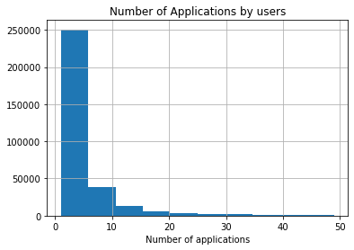

```python
users_grouped[users_grouped.JobID<50].JobID.hist()
plt.title("Number of Applications by users")
plt.xlabel("Number of applications")
plt.show()
```

```python
#we do not need the users that have only one interaction
(users_grouped["JobID"]>1).astype(int).sum()
```

```
212990
```

### Prepare test data

First make sure it is completely shuffled, to make a random train-test split.

```python
shuffled_users_grouped = df_apps[df_apps.UserID.isin(users_grouped[(users_grouped["JobID"]>=4)].index)].sample(frac = 1, replace = False, random_state = 12)
```

```python
shuffled_users_grouped["row_number_by_user_id"] = shuffled_users_grouped.groupby(["UserID"]).cumcount()
```

```python
test1 = shuffled_users_grouped[shuffled_users_grouped.row_number_by_user_id == 4]
test2 = shuffled_users_grouped[shuffled_users_grouped.row_number_by_user_id > 4].sample(frac = 0.16, replace = False, random_state = 12)
```

```python
test = pd.concat([test1, test2])[["JobID", "UserID", "applied"]]
```

### Prepare train data

From users with 2 interactions or more minus the test data

```python
train_over1 = df_apps[df_apps.UserID.isin(users_grouped[(users_grouped["JobID"]>1)].index)]
```

```python
train = train_over1[~train_over1.index.isin(test.index)]
```

### Test Recommendation model

```python
sparse_train = csr_matrix((train["applied"], (train['JobID'], train['UserID'])))
sparse_test = csr_matrix((test["applied"], (test['JobID'], test['UserID'])))
```

```python
model_als = implicit.als.AlternatingLeastSquares(factors = 5, num_threads = 0)
```

```
WARNING:root:Intel MKL BLAS detected. Its highly recommend to set the environment variable 'export MKL_NUM_THREADS=1' to disable its internal multithreading
```

```python
model_als.fit(sparse_train)
```

```python
mean_average_precision_at_k(model_als, sparse_train.T.tocsr(), sparse_test.T.tocsr(), K=4, num_threads=0)
```

```
0.0015270497822343766
```

```python
mrr = mean_reciprocal_rank(model_als, sparse_train.T.tocsr(), test, user_col = "UserID", item_col = "JobID", N = 20)
```

```python
mrr
```

```
0.004134918507467587
```

### User ID 47

Jobs applied by user 47. As have been seen all jobs applied are in California, under administrative assistance related jobs.

```python
job47 = df_jobs[df_jobs.JobID.isin([169528, 284009, 2121, 848187, 733748, 576958, 262470, 602298])]
job47
```

|  | JobID | WindowID | Title | Description | Requirements | City | State | Country | Zip5 | StartDate | EndDate |
| --- | --- | --- | --- | --- | --- | --- | --- | --- | --- | --- | --- |
| 609 | 2121 | 1 | MEDICAL- FRONT OFFICE | Medical - Front Office\r\nIndustrial Clinic, ... | Please refer to the Job Description to view th... | Los Angeles | CA | US | 90066 | 2012-03-09 18:07:59.063 | 2012-04-08 23:59:59 |
| 42812 | 169528 | 1 | Resort Host/Marketing Coordinator - Anaheim, CA | <P STYLE="MARGIN-TOP: 0px; MARGIN-BOTTOM: 0px"... | • Bachelor's Degree preferred;<BR> \r\n• Posse... | Anaheim | CA | US | 92801 | 2012-04-03 22:31:26.41 | 2012-05-02 23:59:59 |
| 66927 | 262470 | 1 | Account Manager- Customer Service | Staffmark has partnered with an aerospace manu... | <strong><span style="text-decoration: underlin... | Buena Park | CA | US | 90620 | 2012-04-04 17:07:51.35 | 2012-05-03 23:59:59 |
| 72124 | 284009 | 1 | Administrative Assistant | <p><strong>Administrative Assistant $60K - $65... | Requirement:&nbsp; 2-4 years of significant ex... | Los Angeles | CA | US | 90036 | 2012-03-26 00:22:39.093 | 2012-04-25 23:59:59 |
| 146896 | 576958 | 1 | RECEPTIONIST | WE NEED A SPIRITED, OUT GOING PERSON TO JOIN O... | GREET ALL PATIENTS WITH A SMILE AND BY NAME <... | San Gabriel | CA | US | 91775 | 2012-03-11 11:43:48.003 | 2012-04-10 23:59:59 |
| 153547 | 602298 | 1 | Customer Service Rep. | Customer Service Customer Service Rep. SANTA M... | Please refer to the Job Description to view th... | Rancho Dominguez | CA | US | 90220 | 2012-03-23 16:10:51.293 | 2012-04-22 23:59:59 |
| 187487 | 733748 | 1 | Administrative Assistant | One of the largest oilfield services companies... | NaN | Long Beach | CA | US | NaN | 2012-03-07 06:43:12.37 | 2012-04-06 23:59:59 |
| 216275 | 848187 | 1 | Administrative Assistant | <DIV>\r<P><SPAN>ADMINISTRATIVE ASSISTANT</SPAN... | <P><SPAN style="TEXT-DECORATION: underline"></... | Los Angeles | CA | US | 90071 | 2012-03-19 17:55:56.67 | 2012-04-18 23:59:59 |

### Recommended jobs for user 47

```python
model_als.recommend(47, sparse_train.T.tocsr(), N = 10)
```

```
[(368785, 0.00017041831),
 (67239, 0.00016367839),
 (450024, 0.00016075425),
 (507808, 0.00014856747),
 (80965, 0.00013715189),
 (959833, 0.00013379121),
 (42838, 0.00013284138),
 (554905, 0.000124313),
 (282190, 0.00012277815),
 (475953, 0.00012228775)]
```

```python
recommended_job47 = df_jobs[df_jobs.JobID.isin([368785, 67239, 450024, 507808, 80965, 959833, 42838, 554905, 282190, 475953])]
recommended_job47
```

|  | JobID | WindowID | Title | Description | Requirements | City | State | Country | Zip5 | StartDate | EndDate |
| --- | --- | --- | --- | --- | --- | --- | --- | --- | --- | --- | --- |
| 725879 | 42838 | 5 | Receptionist/ Accounting Assistant | I have a key client in Buckhead that is lookin... | <p style="text-align: justify"><span>ESSENTIAL... | Atlanta | GA | US | 30326 | 2012-05-21 16:44:03.247 | 2012-06-20 23:59:00 |
| 729105 | 67239 | 5 | Scheduler | <div>\r<p><span style="text-decoration: underl... | see job description | Atlanta | GA | US | NaN | 2012-05-22 15:36:59.42 | 2012-06-21 23:59:00 |
| 730971 | 80965 | 5 | Admissions Representative | <p style="text-align: justify">John Casablanca... | <p style="text-align: justify"><b><span style=... | Atlanta | GA | US | NaN | 2012-05-15 14:47:56.833 | 2012-06-14 23:59:59 |
| 755817 | 282190 | 5 | Patient Services Representative | <DIV>\r<P style="LINE-HEIGHT: 12.65pt; WIDOWS:... | <UL>\r <LI style="COLOR: black"><SPAN style... | Marietta | GA | US | 30060 | 2012-05-08 11:49:16.307 | 2012-06-07 23:59:59 |
| 767140 | 368785 | 5 | Administrative Assistant | <p><span>The primary responsibility of an Admi... | <p><b>Knowledge, Skills, Abilities and Other C... | Atlanta | GA | US | 30350 | 2012-05-23 11:21:03.98 | 2012-06-22 23:59:00 |
| 777601 | 450024 | 5 | Customer Service Representative | Ultimate Staffing Service is currently recruit... | <p><b><span>(The knowledge/skills required to ... | Atlanta | GA | US | 30339 | 2012-05-04 17:40:24.82 | 2012-06-03 23:59:59 |
| 780862 | 475953 | 5 | Insurance Verification Specialist | <P><B>Radiation Oncology Services of America</... | <UL>\r <LI><SPAN>Associates Degree in Busin... | Alpharetta | GA | US | 30005 | 2012-05-16 12:03:22.867 | 2012-06-15 23:59:00 |
| 784770 | 507808 | 5 | Mortgage Call Center Representative | <p>Amerisave is looking for successful loan of... | <sub><br />\r<p>&nbsp;</p>\r<sub><sub>\r<p>At ... | Atlanta | GA | US | NaN | 2012-05-15 13:54:36.377 | 2012-06-14 23:59:00 |
| 790238 | 554905 | 5 | Registration Representative | <P>C4 Connections is Now Accepting Application... | <P>What's Required? </P>\r<P> </P>\r<P>C4 is l... | Atlanta | GA | US | 30305 | 2012-05-21 15:08:28.847 | 2012-06-20 23:59:00 |
| 841896 | 959833 | 5 | Scheduler and Executive Assistant | <p><span></span></p>\r<p align="left"><span>MI... | <p><span>The qualified individual will be resp... | Suwanee | GA | US | NaN | 2012-05-10 17:33:24.76 | 2012-06-09 23:59:59 |

### Jobs in California State

Since I have assumed that user with ID 47 is from California state.  
We can also use **similar_items** and **similar_users** to find similar job posts and similar users.

```python
top_200_cal = df_apps[df_apps.JobID.isin(df_jobs[df_jobs.State == "CA"].JobID.to_numpy())].JobID.to_numpy()[:200]
cal_items47 = model_als.rank_items(47, sparse_train.T.tocsr(), top_200_cal)
```

```python
recommended_cal_job47 = df_jobs[df_jobs.JobID.isin(np.array(cal_items47)[:, 0][0:10])]
recommended_cal_job47
```

|  | JobID | WindowID | Title | Description | Requirements | City | State | Country | Zip5 | StartDate | EndDate |
| --- | --- | --- | --- | --- | --- | --- | --- | --- | --- | --- | --- |
| 46184 | 180313 | 1 | Administrative Assistant | Volt is currently looking for an experienced A... | Qualified individuals will have 2-5 years of e... | San Diego | CA | US | 92123 | 2012-04-04 08:02:49.893 | 2012-05-03 23:59:59 |
| 121075 | 476989 | 1 | CUSTOMER SERVICE - Marketing Firm | <span>\r<div>\r<div style="text-align: center"... | <div style="text-align: center">Requirements<b... | Los Angeles | CA | US | 90230 | 2012-03-26 12:37:58.72 | 2012-04-25 23:59:59 |
| 122410 | 480634 | 1 | Administrative Positions | Volt is looking for multiple clerical/administ... | Must have 2-5 years of recent related work exp... | San Diego | CA | US | 92131 | 2012-04-04 20:02:19.353 | 2012-05-03 23:59:59 |
| 123369 | 485345 | 1 | Sales - Sales Management (Sales and Marketing) | <p><strong><span>Job Description</span></stron... | <hr>\r<p><strong>Job Requirements</strong> </p... | Anaheim | CA | US | NaN | 2012-03-13 08:31:23.483 | 2012-04-12 23:59:59 |
| 147673 | 580916 | 1 | Account Executive (Home Based Office) | <p><span>The <b>Account Executive</b>, working... | <ul>\r <li>3+ years business-to-business sa... | San Diego | CA | US | NaN | 2012-04-02 15:03:45.563 | 2012-05-01 23:59:59 |
| 160504 | 628251 | 1 | Accounting Manager | <DIV align=center>\r<HR>\r</DIV>\r<P align=cen... | <UL style="MARGIN-TOP: 0in" type=disc>\r <L... | Santa Fe Springs | CA | US | NaN | 2012-03-08 19:21:25.857 | 2012-04-07 23:59:59 |
| 187386 | 733218 | 1 | FULL TIME CUSTOMER SERVICE POSITIONS AVAILABLE... | <p style="text-align: center" align="center"><... | <br />\r<br />\r<p style="text-align: center" ... | Van Nuys | CA | US | 91406 | 2012-03-27 14:55:41.003 | 2012-04-26 23:59:59 |
| 216275 | 848187 | 1 | Administrative Assistant | <DIV>\r<P><SPAN>ADMINISTRATIVE ASSISTANT</SPAN... | <P><SPAN style="TEXT-DECORATION: underline"></... | Los Angeles | CA | US | 90071 | 2012-03-19 17:55:56.67 | 2012-04-18 23:59:59 |
| 280969 | 1100659 | 1 | Sales Representative | <p align="justify"><span>Established Southern ... | <p align="justify"><span>Candidates must have ... | South Gate | CA | US | 90280 | 2012-03-15 14:22:00.02 | 2012-04-14 23:59:59 |